# Zona Limpia vs modelo: selección diaria

Comparación a igual cantidad de visitas diarias

## Objetivo

Este reporte compara dos mecanismos de selección de clusters:

- la selección efectiva visitada por Zona Limpia;
- el top N diario sugerido por el modelo `logistico_reducido_d2`.

La comparación usa el mismo N por día: si Zona Limpia tuvo `n_visitas_zl` visitas efectivas, el modelo selecciona los `n_visitas_zl` clusters con mayor score ese mismo día.

Se muestran dos objetivos distintos:

- **problema real observado**: reclamo COM o problema comparable observado por Zona Limpia;
- **reclamo COM**: solo reclamos COM, que corresponde al objetivo original del modelo.

`Voluminosos` no cuenta como problema en la métrica principal.

## Resumen Mensual

Cada mes resume comparaciones diarias a igual cantidad de puntos: para cada día, el modelo COM elige la misma cantidad de clusters que visito Zona Limpia.

- `ZL` refiere a la selección efectivamente visitada por Zona Limpia.
- `Modelo` refiere al top N diario del modelo COM `logistico_reducido_d2`.
- `Problemas` cuenta clusters con reclamo COM o problema comparable observado por Zona Limpia.
- `COM` cuenta clusters con reclamo COM.
- Las tasas se calculan dividiendo por la cantidad de visitas/puntos seleccionados.

Nota metodologica: este reporte compara la selección efectiva de Zona Limpia contra el modelo COM existente. No usa el modelo ZL puro.

Resumen mensual a igual cantidad de visitas diarias

| Mes | Visitas ZL | Problemas ZL | Problemas modelo | Tasa problema ZL | Tasa problema modelo | COM ZL | COM modelo | Tasa COM ZL | Tasa COM modelo |
| --- | --- | --- | --- | --- | --- | --- | --- | --- | --- |
| Marzo | 15.432 | 8.066 | 5.433 | 52,3% | 35,2% | 1.176 | 5.093 | 7,6% | 33,0% |
| Abril | 29.150 | 17.654 | 11.285 | 60,6% | 38,7% | 2.917 | 9.336 | 10,0% | 32,0% |
| Mayo | 22.705 | 12.997 | 8.071 | 57,2% | 35,5% | 2.068 | 5.998 | 9,1% | 26,4% |

## Tasa Diaria Por Objetivo

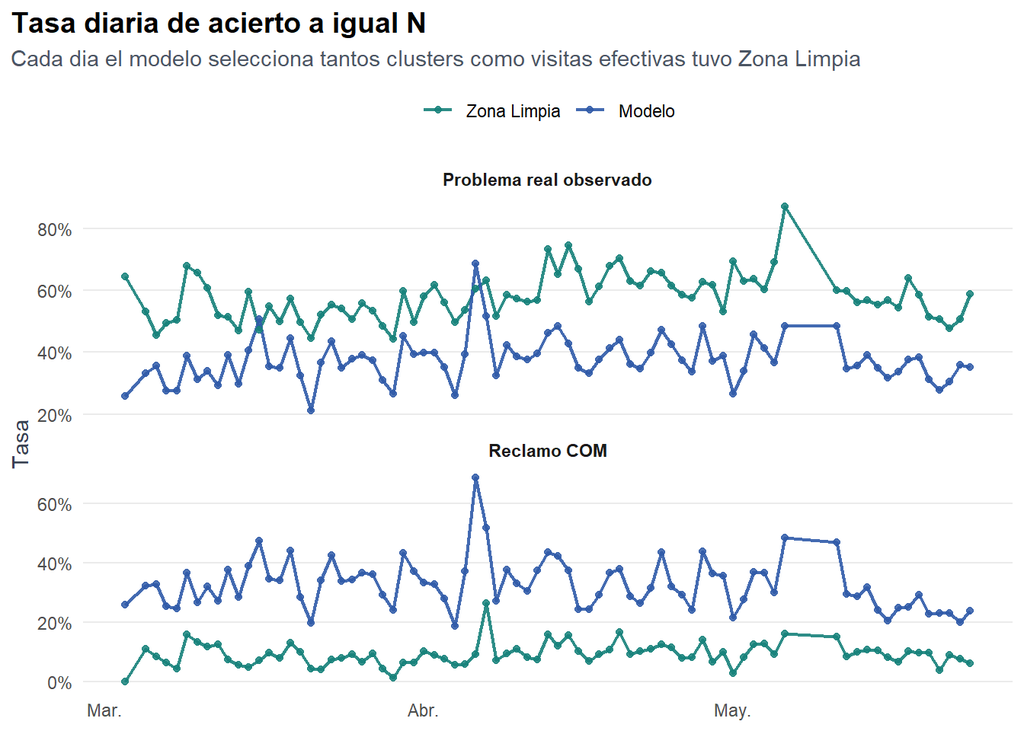

## Tasas Agregadas Por Mes

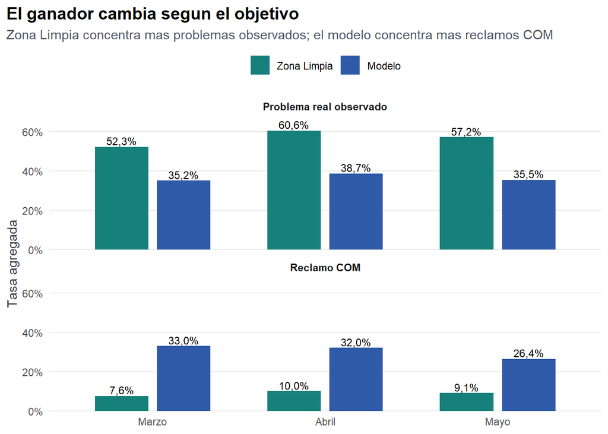

## Diferencia Diaria Modelo Menos Zona Limpia

Valores positivos favorecen al modelo. Valores negativos favorecen a Zona Limpia.

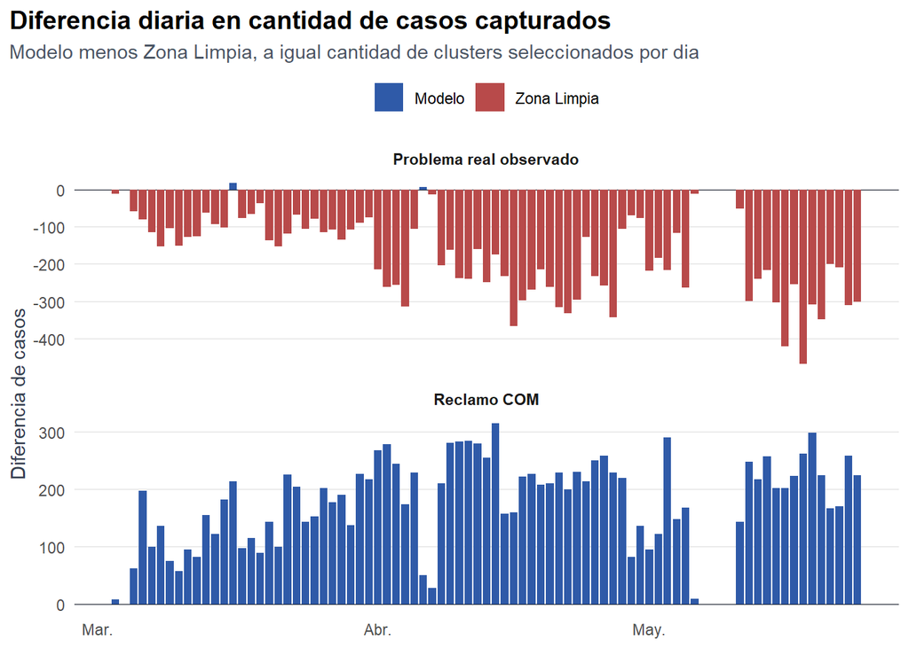

Las barras anteriores son la lectura central del reporte: cuando la diferencia se calcula sobre problemas reales observados, predominan valores negativos; al calcularla solo sobre reclamos COM, predominan valores positivos. Esto muestra que el mecanismo actual de Zona Limpia y el modelo COM priorizan objetivos distintos.

## Solapamiento Entre Selecciones

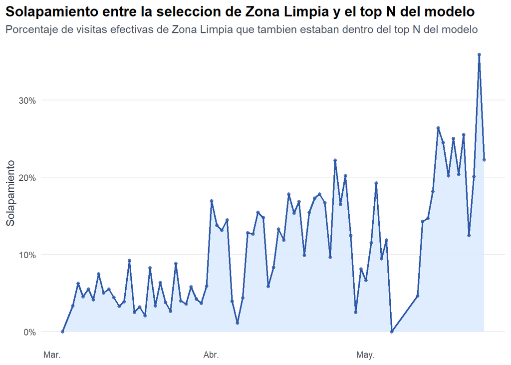

## Lectura

La evidencia apunta a dos objetivos distintos:

- si la meta es detectar problemas observados en campo, la selección efectiva de Zona Limpia concentra más casos;
- si la meta es anticipar reclamos COM, el modelo concentra muchos más reclamos que la selección de Zona Limpia a igual cantidad de visitas.

La primera comparación es conservadora para el modelo, porque los problemas sin reclamo COM solo son observables cuando Zona Limpia efectivamente visito el cluster.